# Animated graphs

# Animated graphs

This page provides a brief explanation on how to make animated graphs. Animated graphs help present information that changes over a time period (such as years) or space (such as by state).

## Keep in Mind

- Animated graphs can be in any shape line, plot, bar, etc.
- To show changes in your data, it is easier to graph fewer groups; however, data manipulation and creative use of color palates allow people to work around this barrier and expand the number of groups they want to show.
- Each animation duration and number of frames depends on the given inputs.
- The height and width dimensions are important for presenting the animated details

## Also Consider

- You may need to do some data manipulation to create the right animated graph.
- Check the presentation [Figures]({{ “/Presentation/Figures/Figures.html” | relative_url }}), there are many charts we can animate.

# Implementations

Notes on implementations:

## R

There are many great packages to do animated graphs such as gganimate and plotly. Here we used gganimate and ggplot2 to do animated bar graphs, and gifski to save the results.

In R, one of the best tools for creating graphs is the function ggplot(), found in the ggplot2 package.

For this R demonstration, we will introduce how to use ggplot2 package to create Animated graphs. First, we load all the packages we need.

```r
# Load in necessary packages
library(ggplot2)
library(gganimate)
library(gifski)
library(dplyr)
# Load in desired data (gapminder)
library(gapminder)
```

## Animated bar charts

### example for animated bar charts shows comparisinf over time for two countries.

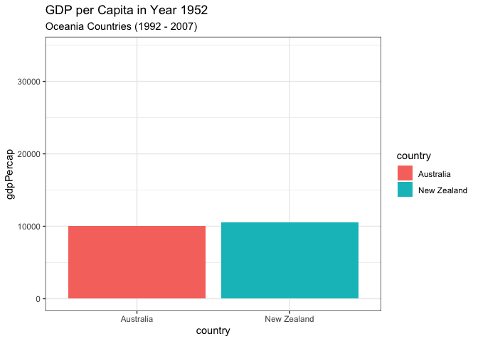

```r
graph_data1 <- gapminder  %>% filter(continent=="Oceania")

# first use ggplot for the graph
ggplot(graph_data1, aes(x=country, y=gdpPercap, fill=country)) +
  geom_bar(stat='identity') +
  theme_bw() + # then set the gganimate,
  transition_states( # to specify the transition, here we specify
    year,
    transition_length = 2,
    state_length = 1) +
  ease_aes('sine-in-out') + # to control easing of aesthetics
  labs(title = 'GDP per Capita in Year {closest_state}', # title with the timestamp period
  subtitle = 'Oceania Countries (1992 - 2007)')
```

```r
anim_save("graph1.gif") # to save the graph as gif
```

### example for animated bars for 25 countries over time.

```r
graph_data <- gapminder %>% filter(continent=="Americas")

# Plot bar graphs by country, we have 25 countries in the Americas, that hard to interpretation using one graph.
# this example shows how gganimate can create a nice animated graph even with that high number of countries

graph_2 <- ggplot(graph_data, aes(x=country, y=gdpPercap, fill=country)) +
  geom_bar(stat='identity') +
  theme_bw() + # gganimate specific bits:
  transition_states(
    year,
    transition_length = 2,
    state_length = 1) +
  ease_aes('sine-in-out')+
  theme(axis.text=element_blank(),
        axis.title.x=element_blank(),
        legend.position="center",
        panel.border=element_blank(),
        axis.title.y=element_text(size=20),
        axis.text.y = element_text(hjust=1, size=16),
        axis.text.x = element_text(angle = 45, hjust=1, size=16),
        plot.title=element_text(size=25, hjust=0.5, face="bold", colour="black", vjust=1),
        plot.subtitle=element_text(size=24, hjust=0.5, face="italic", color="grey"),
        plot.margin = margin(2, 2, 4, 4, "cm"))+
  labs(title = 'GDP per Capita for Year {closest_state}', # title with the timestamp period
  subtitle = 'Countries in North and South America (1992 - 2007)')
```

### Save it as gif file formate using animated function

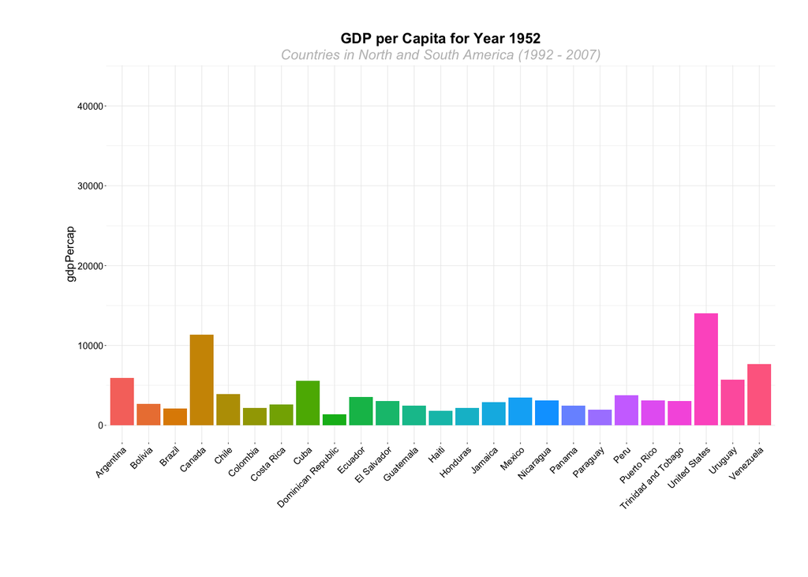

```r
# The animated sitting, create an image per frame, in this example, we used year so it creates an image for each year
animate(graph_2, 100, fps = 20, end_pause=30,  width = 1400, height = 1000,
        renderer = gifski_renderer("gganim1.gif"))
```

## Animatrd Line Chart

[figure not shown]

```r
# Plot North America, here we try line graph by only graph North America countries
graph_data3 <- graph_data %>% filter(country %in% c("United States", "Canada", "Mexico"))

# Plot line graph
graph_3 <- ggplot(data = graph_data3) +
  geom_line(mapping = aes(x=year, y=lifeExp, color=country)) +
  theme_bw() +
  theme(legend.position = "right") +
  labs(title = 'Life Expectancy in North America (1992 - 2007)')+
    transition_reveal(year) + #Reveal data along a given dimension
  ease_aes('linear') # The values change linearly during tweening

graph_3
```

```r
anim_save("graph_3.gif") # to save the graph as gif
```